# Project 1, Group 3

#### Group 3: Christopher Winton, Surya Singh, Joseph Hughes, Kolby Thrasher, Ethan Sutherland

### Introduction

The data being analyzed is financial stock data for the DalTile location in Sunnyvale, TX and it was obtained in June of 2017. This data was obtained by Joseph Hughes from the company’s SAP software. Joseph was given permission to use this data in a non-commercial setting by his former supervisor Roy Huffman who is the Maintenance and Engineering Supervisor of this plant location.

### Quatlitative Data Question 1

```r
kable(Depts)
```

| Names | Frequency | Cumulative Frequency | Relative Frequency | Cumulative Relative Frequency |
| --- | --- | --- | --- | --- |
| ASSORTED | 392 | 392 | 0.0359 | 0.036 |
| BELTS | 743 | 1135 | 0.0681 | 0.104 |
| BODY PREP | 7 | 1142 | 0.0006 | 0.105 |
| FASTENAL/MISC. | 202 | 1344 | 0.0185 | 0.123 |
| GENERAL | 1 | 1345 | 0.0001 | 0.123 |
| GENERAL/SHAFT | 418 | 1763 | 0.0383 | 0.162 |
| GUIDE MATS | 204 | 1967 | 0.0187 | 0.180 |
| JANITORIAL | 1 | 1968 | 0.0001 | 0.180 |
| MOTORS | 285 | 2253 | 0.0261 | 0.206 |
| P1 BODY PREP/GLAZE PREP | 389 | 2642 | 0.0356 | 0.242 |
| P1 DRYER | 91 | 2733 | 0.0083 | 0.250 |
| P1 ELECTRICAL | 386 | 3119 | 0.0354 | 0.286 |
| P1 GLAZELINE | 343 | 3462 | 0.0314 | 0.317 |
| P1 KILN | 279 | 3741 | 0.0256 | 0.343 |
| P1 LOADER/UNLOADER | 404 | 4145 | 0.0370 | 0.380 |
| P1 PACKAGING/SELECTION | 755 | 4900 | 0.0692 | 0.449 |
| P1 PRESS | 785 | 5685 | 0.0719 | 0.521 |
| P1 TRANSPORT | 151 | 5836 | 0.0138 | 0.535 |
| P2 BODY PREP | 481 | 6317 | 0.0441 | 0.579 |
| P2 DRYER | 137 | 6454 | 0.0126 | 0.591 |
| P2 ELECTRICAL | 386 | 6840 | 0.0354 | 0.627 |
| P2 GLAZELINE | 137 | 6977 | 0.0126 | 0.639 |
| P2 KILN | 183 | 7160 | 0.0168 | 0.656 |
| P2 PACKAGING/SELECTION | 1413 | 8573 | 0.1295 | 0.786 |
| P2 PRESS | 503 | 9076 | 0.0461 | 0.832 |
| P2 TRANSPORT | 468 | 9544 | 0.0429 | 0.875 |
| PLUMBING | 239 | 9783 | 0.0219 | 0.896 |
| POWER TRANSMISSION | 432 | 10215 | 0.0396 | 0.936 |
| PRESS | 55 | 10270 | 0.0050 | 0.941 |
| REDUCERS | 226 | 10496 | 0.0207 | 0.962 |
| ROLLERS | 14 | 10510 | 0.0013 | 0.963 |
| ROLLERS/GUIDES | 102 | 10612 | 0.0093 | 0.972 |
| SHAFT/GUIDES | 303 | 10915 | 0.0278 | 1.000 |

#### Discussion

In this table we have calculated Frequency,cumulative frequency, relative frequency and cumulative relative frequency from the column department of the data.

### Quatlitative Data Question 2

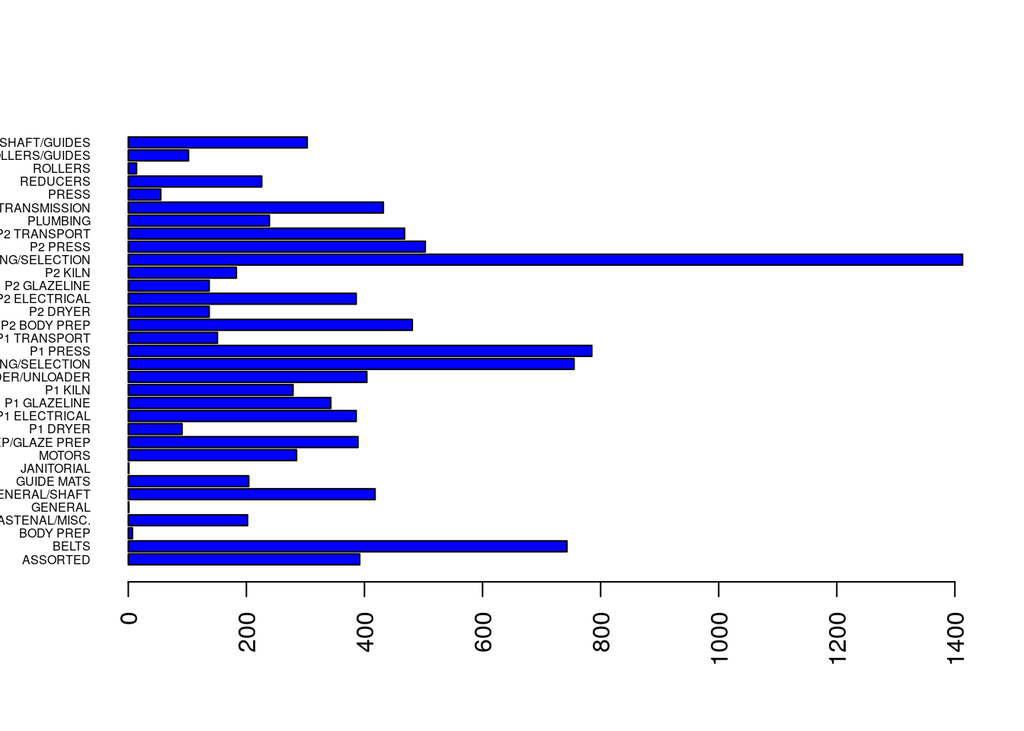

```r
barplot(horiz = T, countDept$freq, names.arg = countDept$x, las = 2, cex.axis = 1, cex.names = 0.5, col = c("blue"))
```

### Quantitative Data Question 1

```r
kable(valTable)
```

| Mean | Median | MAD | Variance | Standard Deviation |
| --- | --- | --- | --- | --- |
| 2087.08 | 1756.35 | 825.59 | 998398.3 | 999.2 |

### Quantitative Data Question 2

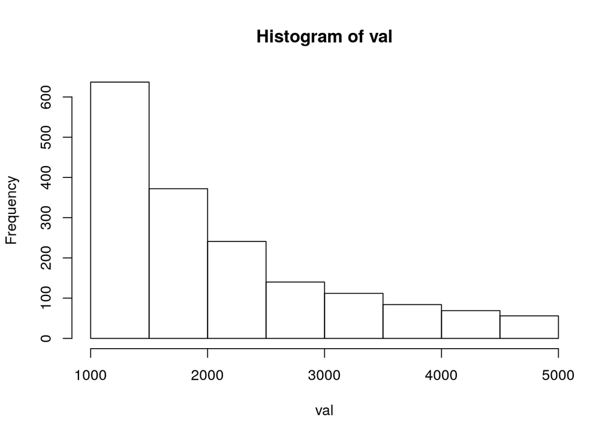

```r
hist(val)
```

### Quantitative Data Question 3

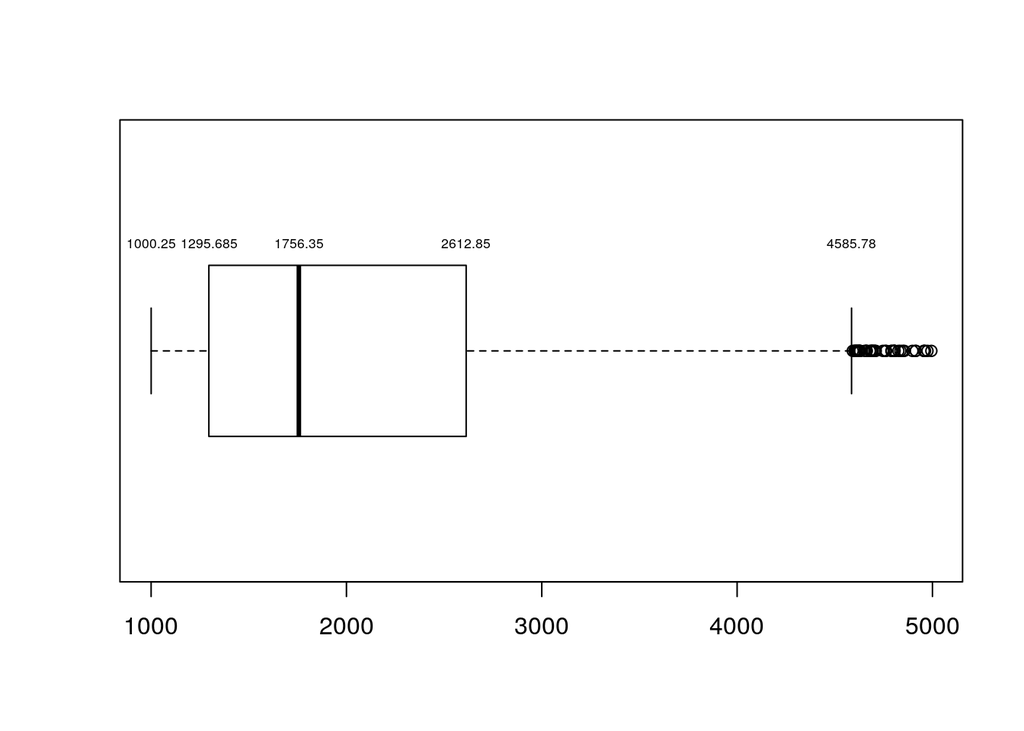

```r
boxplot(val,horizontal = T)
lbs<-boxplot.stats(val)$stats
text(lbs,labels=lbs, y = 1.25, cex = 0.55)
```

### Questions

1. Which department spends the most money on spare parts?
2. Which department is the most cost-effective?
3. Which department most-frequently purchases spare parts?